# Hiszpańskie Wina

Patryk Góreczny, Kamil Husak, Mateusz Filas

2022-05-12

knitr::opts_chunk$set(echo = TRUE)

# • Przedstawienie zagadnienia, przedstawienie danych

Ramka danych, którą będziemy analizować zawiera 7500 różnych czerwonych win pochodzenia Hiszpaśkiego, które opisane są przez jedenaście cech takich jak np. cena, region, winiarnia. Dane zostały zebrane za pomocą web scrapingu z różnych źródeł (od stron specjalizujących się w winach po supermarkety).

Informacje o cechach:

1. **winery** - nazwa winiarni
2. **wine** - nazwa wina
3. **year** - rok, w którym zebrano winogrona
4. **rating** - średnia ocena wina przyznana przez użytkowników
5. **num_reviews** - liczba użytkowników, która oceniła wino
6. **country** - kraj pochodzenia wina
7. **region** - region, z którego pochodzi wino
8. **price** - cena wina w €
9. **typ** - typ wina
10. **body** - smak wina definiowany jako bogactwo i waga wina w ustach
11. **acidity** - ocena kwasowości wina

**Źródło danych** - [kaggle.com](https://www.kaggle.com/datasets/fedesoriano/spanish-wine-quality-dataset?fbclid=IwAR0PPTKB_U7lC_qTS9a6b1iytN-33YwvL6CfxyjrEDLl09JlKwgXAvRulUw)

Przedstawienie danych za pomocą funkcji `summary`.

```r
dane <- read.csv("wines_SPA.csv")
summary(dane)
```

```
##     winery              wine               year               rating
##  Length:7500        Length:7500        Length:7500        Min.   :4.200
##  Class :character   Class :character   Class :character   1st Qu.:4.200
##  Mode  :character   Mode  :character   Mode  :character   Median :4.200
##                                                           Mean   :4.255
##                                                           3rd Qu.:4.200
##                                                           Max.   :4.900
##
##   num_reviews        country             region              price
##  Min.   :   25.0   Length:7500        Length:7500        Min.   :   4.99
##  1st Qu.:  389.0   Class :character   Class :character   1st Qu.:  18.90
##  Median :  404.0   Mode  :character   Mode  :character   Median :  28.53
##  Mean   :  451.1                                         Mean   :  60.10
##  3rd Qu.:  415.0                                         3rd Qu.:  51.35
##  Max.   :32624.0                                         Max.   :3119.08
##
##      type                body          acidity
##  Length:7500        Min.   :2.000   Min.   :1.000
##  Class :character   1st Qu.:4.000   1st Qu.:3.000
##  Mode  :character   Median :4.000   Median :3.000
##                     Mean   :4.158   Mean   :2.947
##                     3rd Qu.:5.000   3rd Qu.:3.000
##                     Max.   :5.000   Max.   :3.000
##                     NA's   :1169    NA's   :1169
```

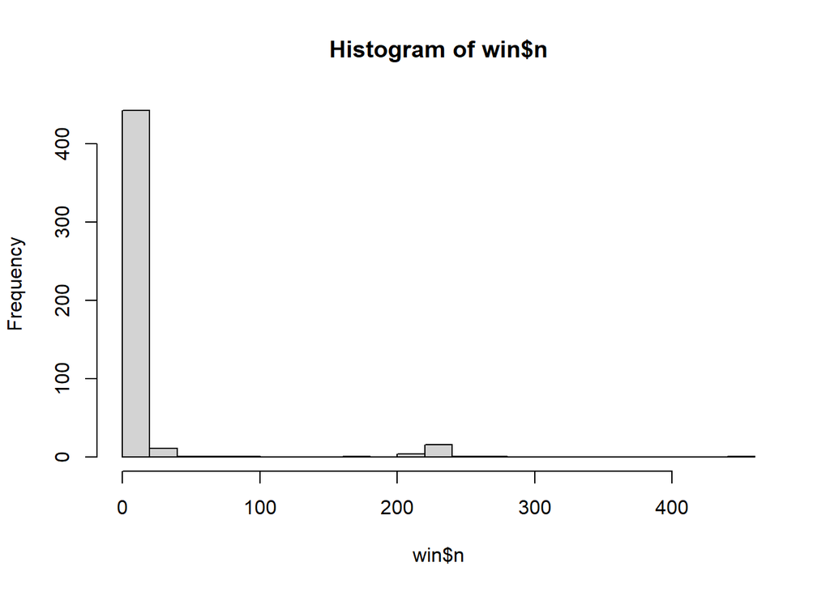

```r
win <- dane %>% count(winery)
hist(win$n, breaks = 30)
```

- Możemy zauważyć, że większość winiarni posiada tylko nieznaczną część wszystkich win

Ta sama sytuacja pojawia się w przypadku:

- regionów

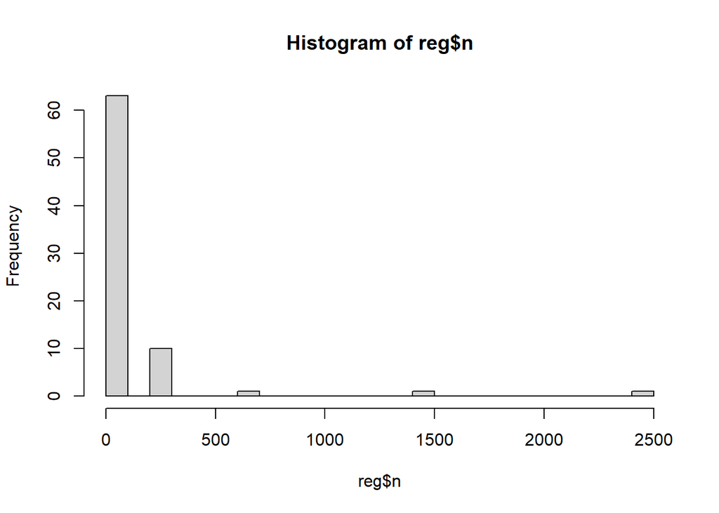

```r
reg <- dane %>% count(region)
hist(reg$n, breaks = 30)
```

- typów wina

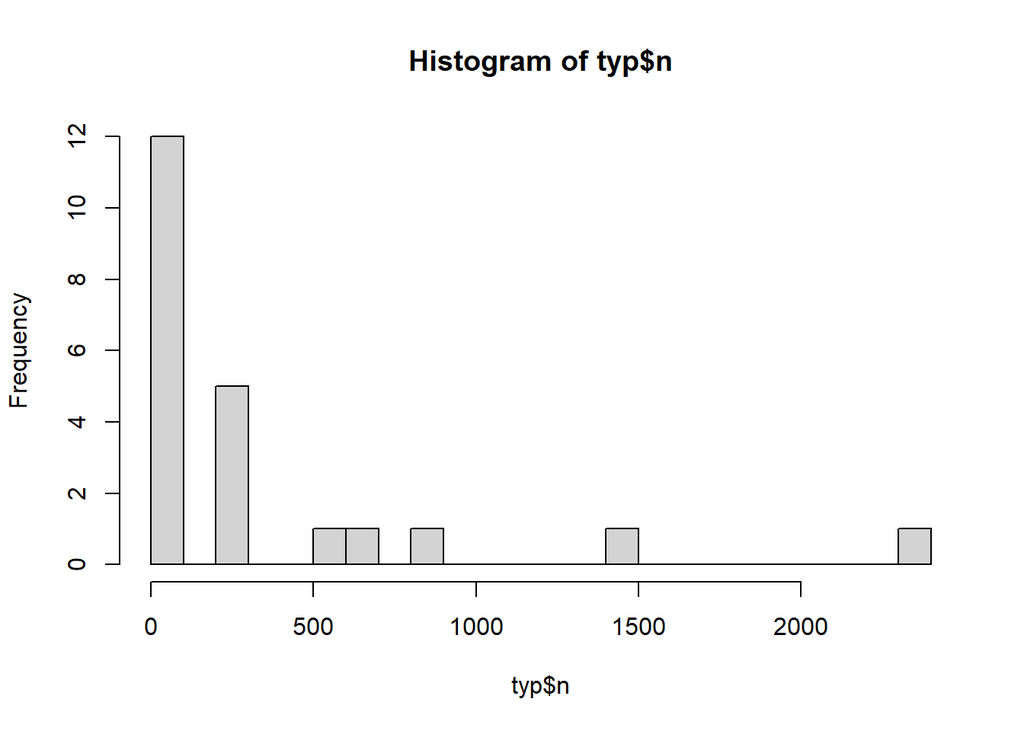

```r
typ <- dane %>% count(type)
hist(typ$n, breaks = 30)
```

- samych win

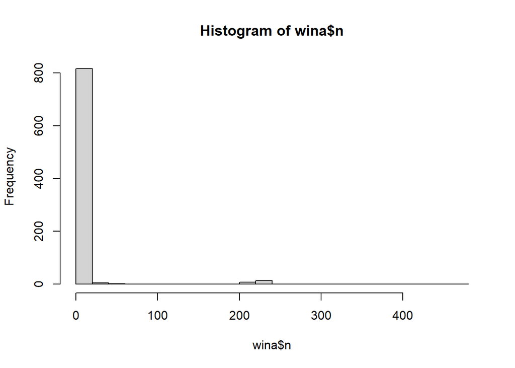

```r
wina <- dane %>% count(wine)
hist(wina$n, breaks = 30)
```

Kilka wykresów obrazujących inne problemy z naszymi danymi

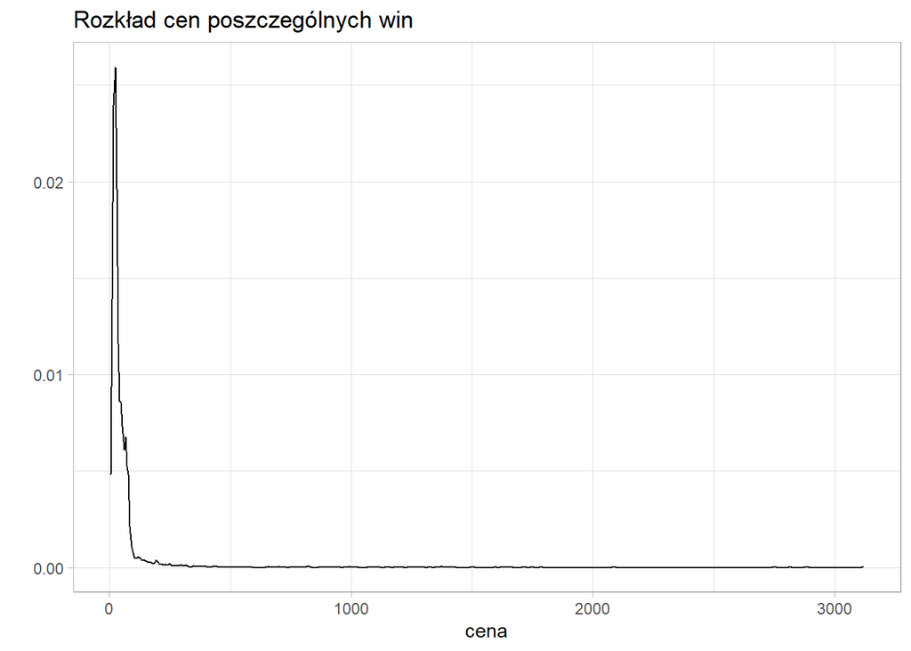

```r
ggplot(dane, aes(price)) +
  geom_density() +
  labs(title = "Rozkład cen poszczególnych win", x = "cena", y = "") +
  theme_light()
```

- Rozkład gęstości cen win uwidacznia bardzo długi ogon

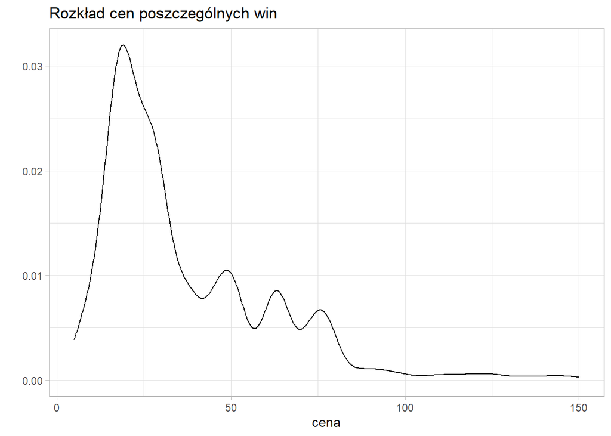

```r
dane0 <- dane %>% filter(price <= 150)
ggplot(dane0, aes(price)) +
  geom_density() +
  labs(title = "Rozkład cen poszczególnych win", x = "cena", y = "") +
  theme_light()
```

```r
dane1 <- dane %>% filter(price <= 80)
nrow(dane1)/nrow(dane)
```

```
## [1] 0.9101333
```

- Zauważmy, że ponad 90% win kosztuje mniej niż 80€

Teraz zobaczmy jak wygląda rozkład liczby ocen win

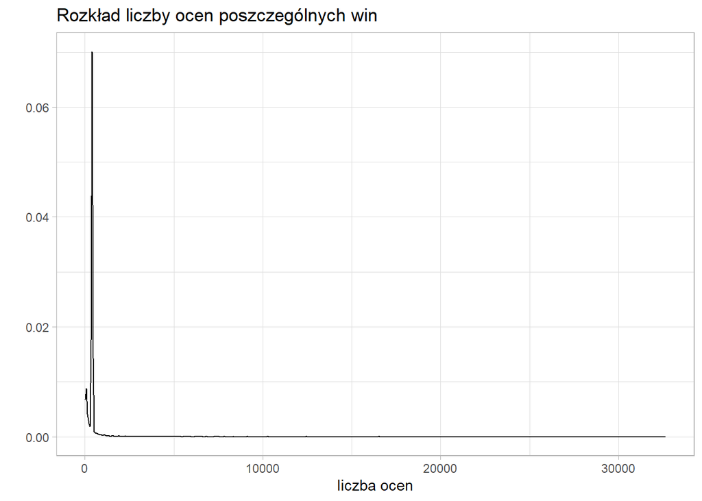

```r
ggplot(dane, aes(num_reviews)) +
  geom_density() +
  labs(title = "Rozkład liczby ocen poszczególnych win", x = "liczba ocen", y = "") +
  theme_light()
```

- W tym przypadku również możemy zaobserwować podobną sytuację jak w przypadku cen wina

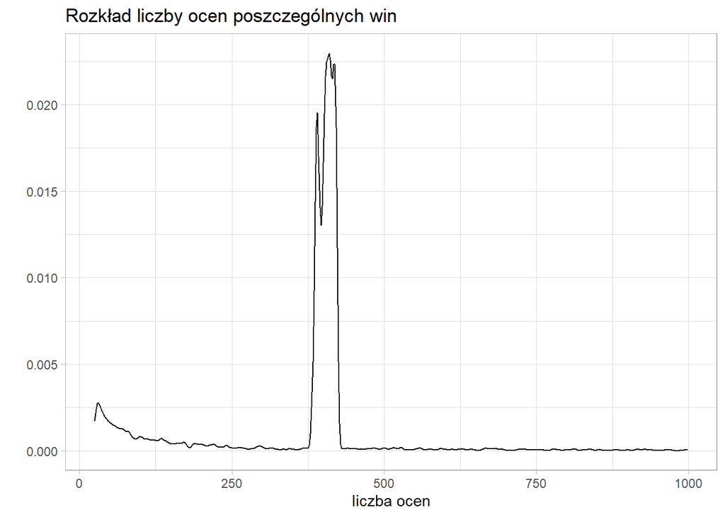

```r
dane2 <- dane %>% filter(num_reviews <= 1000)
ggplot(dane2, aes(num_reviews)) +
  geom_density() +
  labs(title = "Rozkład liczby ocen poszczególnych win", x = "liczba ocen", y = "") +
  theme_light()
```

```r
dane3 <- dane %>% filter(num_reviews <= 800, num_reviews >= 100)
nrow(dane3)/nrow(dane)
```

```
## [1] 0.8442667
```

- Liczba ocen dla ponad 84% win mieści się w przedziale od 100 do 800.

Możemy również zobaczyć, że kolumna **body** zawiera wartości od 2 do 5, z czego wartości równych 2 jest zdecydowanie za mało, żeby brać je pod uwagę.

```r
dane %>% count(body)
```

```
##   body    n
## 1    2   34
## 2    3  553
## 3    4 4120
## 4    5 1624
## 5   NA 1169
```

```r
dane %>% count(acidity)
```

```
##   acidity    n
## 1       1   35
## 2       2  268
## 3       3 6028
## 4      NA 1169
```

# • Transformacje wykonane na danych (np. usuwanie braków, usuwanie zmiennych, modyfikacja)

Wczytujemy dane z pliku wines_SPA Wstępna analiza naszych danych pokazała kilka rzeczy, które należy poprawić. Po pierwsze usuwamy zbędną kolumnę **country**, ponieważ występuje w niej jedna i ta sama wartość - Espana. Następnie musimy usunąć ‘ogon’ dla cen win oraz liczby ocen, aby nie zakłamywały wyników. Usuwamy też wiersze, w których nie ma informacji o roku produkcji, a także te wiersze, w których **body** = 2 oraz **acidity** = 1, ponieważ wartości te przyjmowane są zbyt rzadko, by brać je pod uwagę. Poza tym usuwamy wszystkie wiersze, w których występują jakiekolwiek braki danych. Zdecydowaliśmy się jeszcze na usunięcie kolumny zawierającej informacje o nazwie wina, ponieważ zawiera ona bardzo dużo kategorii, które nie dają nam zbyt wiele informacji.

```r
dane <- read.csv('wines_SPA.csv')
dane <- select(dane, -country, -wine)
dane <- dane[!(dane$price>80),]
dane <- dane[!(dane$num_reviews<100),]
dane <- dane[!(dane$num_reviews>800),]
dane <- dane[!(dane$year=='N.V.'),]
dane <- dane[!(dane$year==''),]
dane <- dane[complete.cases(dane),]
dane <- dane[!(dane$body==2),]
dane <- dane[!(dane$acidity==1),]
```

Następnym etapem jest czyszczenie danych, tzn., że w przypadku niektórych kolumn mamy bardzo dużo różnych wartości, które występują bardzo małą ilość razy i to właśnie te wartości będą sklasyfikowane jako ‘Inne’.

- **Czyszczenie winiarni**

Chcemy zmniejszyć liczbę różnych winiarnii oraz wyrównać ich liczność. Dlatego przyjmujemy, że jeśli dana winiarnia występuje mniej niż 13 razy to zaliczamy ją do ‘Innych’

```r
winiarnie <- data.frame(unique(dane$winery))
for(i in 1:length(unique(dane$winery))){
  winiarnie[i,2] <- sum(dane$winery==winiarnie[i, 1])
}
for(i in 1:length(winiarnie[,1])){
  for(j in 1:length(dane$winery))
  {
    if(winiarnie$unique.dane.winery[i] == dane$winery[j])
    {
      if(winiarnie$V2[i] < 13){
        dane$winery[j] <- 'Inne'
      }
    }
  }
}

winiarnie <- data.frame(unique(dane$winery))
for(i in 1:length(unique(dane$winery))){
  winiarnie[i,2] <- sum(dane$winery==winiarnie[i, 1])
}
```

- **Czyszczenie regionów**

P{odobnie postępujemy z regionami. Jeśli dany region występuje mniej niż 20 razy to zaliczamy go do ‘Innych’

```r
regiony <- data.frame(unique(dane$region))
for(i in 1:length(unique(dane$region))){
 regiony[i,2] <- sum(dane$region==regiony[i, 1])
}
for(i in 1:length(regiony[,1])){
  for(j in 1:length(dane$region))
  {
    if(regiony$unique.dane.region[i] == dane$region[j])
    {
      if(regiony$V2[i] < 20){
        dane$region[j] <- 'Inne'
      }
    }
  }
}

regiony <- data.frame(unique(dane$region))
for(i in 1:length(unique(dane$region))){
  regiony[i,2] <- sum(dane$region==regiony[i, 1])
}
```

- **Czyszczenie typów win**

I znowu robimy to samo dla typów win. eśli dany typ wina występuje mniej niż 70 razy to zaliczamy go do ‘Innych’

```r
typy <- data.frame(unique(dane$type))
for(i in 1:length(unique(dane$type))){
  typy[i,2] <- sum(dane$type==typy[i, 1])
}
for(i in 1:length(typy[,1])){
  for(j in 1:length(dane$type))
  {
    if(typy$unique.dane.type[i] == dane$type[j])
    {
      if(typy$V2[i] < 70){
        dane$type[j] <- 'Inne'
      }
    }
  }
}

typy <- data.frame(unique(dane$type))
for(i in 1:length(unique(dane$type))){
  typy[i,2] <- sum(dane$type==typy[i, 1])
}
```

# • Podział na zbiór treningowy i testowy

```r
dane <- dane %>%
  mutate(across(c("winery", "region", "body", "acidity", "type"), as.factor))

rows <- 1:nrow(dane)
sample_train <- sample(rows, size = round(0.8 * nrow(dane)))
train <- dane %>% slice(sample_train)
test <- dane %>% slice(-sample_train)
```

# • Dobór zmiennych

Przyjmujemy że zmienną objaśnianą w naszym modelu jest cena, a zmiennymi objaśniającymi są wszystkie pozostałe.

```r
model <- lm(price ~ . , data=train)
summary(model)
```

```
##
## Call:
## lm(formula = price ~ ., data = train)
##
## Residuals:
##     Min      1Q  Median      3Q     Max
## -43.675  -0.117   0.000   0.128  40.816
##
## Coefficients: (7 not defined because of singularities)
##                              Estimate Std. Error t value Pr(>|t|)
## (Intercept)                -2.735e+02  1.204e+01 -22.721  < 2e-16 ***
## wineryBodegas La Horra     -2.415e+01  3.728e+00  -6.476 1.06e-10 ***
## wineryCampillo             -3.879e+01  3.872e+00 -10.019  < 2e-16 ***
## wineryClos Pons            -7.429e+01  4.830e+00 -15.381  < 2e-16 ***
## wineryConreria d'Scala Dei -4.218e+01  3.769e+00 -11.193  < 2e-16 ***
## wineryContino              -2.465e+01  3.672e+00  -6.715 2.16e-11 ***
## wineryEnrique Mendoza      -2.234e+01  1.875e+00 -11.917  < 2e-16 ***
## wineryImperial             -2.460e+01  4.320e+00  -5.695 1.33e-08 ***
## wineryInne                 -3.100e+01  3.673e+00  -8.440  < 2e-16 ***
## wineryLa Rioja Alta        -3.165e+01  3.775e+00  -8.384  < 2e-16 ***
## wineryLa Vicalanda         -4.145e+01  3.754e+00 -11.042  < 2e-16 ***
## wineryLosada               -1.575e+01  5.889e+00  -2.674 0.007526 **
## wineryMar de Frades        -2.994e+01  4.127e+00  -7.255 4.83e-13 ***
## wineryMatarromera          -2.220e+01  3.661e+00  -6.064 1.46e-09 ***
## wineryMatsu                -1.671e+01  3.980e+00  -4.199 2.75e-05 ***
## wineryMustiguillo          -1.663e+01  1.873e+00  -8.880  < 2e-16 ***
## wineryPortal del Priorat    8.732e-02  3.784e+00   0.023 0.981588
## wineryRamon Bilbao         -5.473e+01  3.700e+00 -14.795  < 2e-16 ***
## wineryRemirez de Ganuza    -2.941e+01  3.929e+00  -7.484 8.94e-14 ***
## winerySei Solo             -1.904e+01  3.632e+00  -5.243 1.67e-07 ***
## winerySierra Cantabria     -3.322e+01  3.874e+00  -8.576  < 2e-16 ***
## wineryVina Pedrosa         -3.524e+01  3.662e+00  -9.623  < 2e-16 ***
## wineryVinedos de Paganos   -2.670e+01  4.275e+00  -6.246 4.67e-10 ***
## year1998                   -3.857e+01  7.056e+00  -5.466 4.90e-08 ***
## year2001                   -3.010e+01  6.054e+00  -4.972 6.92e-07 ***
## year2002                   -1.186e+01  7.041e+00  -1.685 0.092074 .
## year2004                   -2.607e+01  5.884e+00  -4.432 9.61e-06 ***
## year2005                    3.852e+00  5.865e+00   0.657 0.511315
## year2006                   -2.460e+01  6.079e+00  -4.047 5.30e-05 ***
## year2007                   -2.267e+01  6.066e+00  -3.738 0.000188 ***
```

[output cut: 28 more lines]

```
## typePriorat Red                    NA         NA      NA       NA
## typeRed                    -9.581e+00  1.632e+00  -5.872 4.67e-09 ***
## typeRibera Del Duero Red   -1.274e+01  4.995e+00  -2.551 0.010785 *
## typeRioja Red              -4.475e+00  2.016e+00  -2.219 0.026520 *
## typeTempranillo                    NA         NA      NA       NA
## typeToro Red                       NA         NA      NA       NA
## body4                      -2.514e+00  2.038e+00  -1.234 0.217353
## body5                      -1.106e+01  2.038e+00  -5.427 6.10e-08 ***
## acidity3                           NA         NA      NA       NA
## ---
## Signif. codes:  0 '***' 0.001 '**' 0.01 '*' 0.05 '.' 0.1 ' ' 1
##
## Residual standard error: 4.426 on 3786 degrees of freedom
## Multiple R-squared:  0.9456, Adjusted R-squared:  0.9447
## F-statistic:  1115 on 59 and 3786 DF,  p-value: < 2.2e-16
```

Wyszło nam, że między naszymi zmiennymi występuje współliniowość. Podejrzewamy że dzieje się tak, ponieważ regiony i winiarnie mogą specjalizowac sie w konkretnym typie wina. Dlatego porównamy te dwie zmienne z typami wina

```r
uniqRegion <- unique(dane$region)
uniqType <- unique(dane$type)

df_type_region <- matrix(0,length(uniqRegion),length(uniqType))
df_type_region <- data.frame(df_type_region)
for(i in 1:length(uniqRegion)){
  for(j in 1:length(uniqType)){
     for(k in 1:length(dane$region)){
      if(uniqRegion[i] == dane$region[k])
      {
         if(uniqType[j] == dane$type[k]){
          df_type_region[i,j] <- df_type_region[i,j] + 1
         }
     }
            }
   }
 }
colnames(df_type_region) <- uniqType
rownames(df_type_region) <- uniqRegion
df_type_region
```

```
##                   Ribera Del Duero Red Toro Red Tempranillo Rioja Red Red Inne
## Ribera del Duero                   909        0           1         0   0    0
## Toro                                 0      216           0         0   0    0
## Inne                                 1        0          10         4  41   43
## Rioja                                0        0           1      1835   1   66
## Priorato                             0        0           0         0   0    0
## Rias Baixas                          0        0           0         0   0    0
## Vino de Espana                       0        0         203         0   0    0
## Alicante                             0        0           0         0 202    0
## El Terrerazo                         0        0           0         0 201    0
## Costers del Segre                    0        0           0         0 202    0
## Bierzo                               0        0           0         0   0    0
##                   Priorat Red Albarino Mencia
## Ribera del Duero            0        0      0
## Toro                        0        0      0
## Inne                        0        0      0
## Rioja                       0        0      0
## Priorato                  457        0      0
## Rias Baixas                 0      210      0
## Vino de Espana              0        0      0
## Alicante                    0        0      0
## El Terrerazo                0        0      0
## Costers del Segre           0        0      0
## Bierzo                      0        0    204
```

Możemy zauważyć, że niektóre regiony, są odpowiedzialne za (prawie) całą produkcję danego typu wina. Zmienne te wiec przenoszą praktycznie taką samą informację.

```r
uniqWinery <- unique(dane$winery)
uniqType <- unique(dane$type)

df_type_winery <- matrix(0,length(uniqWinery),length(uniqType))
df_type_winery <- data.frame(df_type_winery)
for(i in 1:length(uniqWinery)){
  for(j in 1:length(uniqType)){
     for(k in 1:length(dane$winery)){
      if(uniqWinery[i] == dane$winery[k])
      {
         if(uniqType[j] == dane$type[k]){
          df_type_winery[i,j] <- df_type_winery[i,j] + 1
         }
     }
            }
   }
 }
colnames(df_type_winery) <- uniqType
rownames(df_type_winery) <- uniqWinery
df_type_region
```

[output not shown]

- **region-cena**

```r
region_cena <- matrix(0,nrow=11,ncol=11)
sumRi <- c()
for(k in 1:11){
  for(j in 1:11){
    sumRi[j] = 0
    for(i in 1:length(dane[,1])){
      if(j==11){
        if(dane$region[i]==regiony$unique.dane.region.[k] & dane$price[i]>=7*j)
          region_cena[k,j]=region_cena[k,j]+1
      }
      if(j<11){
        if(dane$region[i]==regiony$unique.dane.region.[k] & dane$price[i]<7*j & dane$price[i]>=7*j-7  )
          region_cena[k,j]=region_cena[k,j]+1}
    }
  }}
```

Powstaje nam taka macierz:

```r
region_cena
```

```
##       [,1] [,2] [,3] [,4] [,5] [,6] [,7] [,8] [,9] [,10] [,11]
##  [1,]    0    0   11   16  213  215   11  215   11   206     2
##  [2,]    0    0    1  202    3    1    3    3    1     1     1
##  [3,]    0    3   20   18   14   12    8    6    5     7     1
##  [4,]    1  201  406  214  468   13  211   11  209    13     4
##  [5,]    0    0  202    3    2    6    5   11   12     9   204
##  [6,]    0    1  201    1    5    2    0    0    0     0     0
##  [7,]    0    0    0    0    0    0  201    0    2     0     0
##  [8,]    0    0  200    0    1    0    0    0    0     0     0
##  [9,]    0    0    0  200    0    0    0    0    0     0     1
## [10,]    0    0    0  201    0    1    0    0    0     0     0
## [11,]    0    0  200    0    1    3    0    0    0     0     0
```

- **typ-cena**

```r
typ_cena <- matrix(0,nrow=9,ncol=9)
sumTyp <- c()
for(k in 1:9){
  for(j in 1:9){
    sumTyp[j] = 0
    for(i in 1:length(dane[,1])){
      if(j==9){
        if(dane$type[i]==typy$unique.dane.type.[k] & dane$price[i]>=8*j)
          typ_cena[k,j]=typ_cena[k,j]+1
      }
      if(j<9){
        if(dane$type[i]==typy$unique.dane.type.[k] & dane$price[i]<8*j & dane$price[i]>=8*j-8  )
          typ_cena[k,j]=typ_cena[k,j]+1}
    }
  }}
```

Powstaje nam taka macierz:

```r
typ_cena
```

```
##       [,1] [,2] [,3] [,4] [,5] [,6] [,7] [,8] [,9]
##  [1,]    0    1   15  220  215   13  218   10    9
##  [2,]    0    0    1  202    4    2    4    2    1
##  [3,]    0    1    0    1    2    2  199    6    1
##  [4,]    0  202  609  414   19  211   10  208  155
##  [5,]    0    4  413  207   10    4    3    1    4
##  [6,]    1    3   10   64    8    3    9    5    3
##  [7,]    0    0  204    2    5    6   12   13  206
##  [8,]    0    2  200    3    5    0    0    0    0
##  [9,]    0    0  200    1    3    0    0    0    0
```

- **winiarnia-cena**

```r
winiarnia_cena <- matrix(0,nrow=23,ncol=23)
sumWiniarnia <- c()
for(k in 1:23){
  for(j in 1:23){
    sumTyp[j] = 0
    for(i in 1:length(dane[,1])){
      if(j==23){
        if(dane$winery[i]==winiarnie$unique.dane.winery.[k] & dane$price[i]>=7+3*j)
          winiarnia_cena[k,j]=winiarnia_cena[k,j]+1
      }
      if(j<23&j>1){
        if(dane$winery[i]==winiarnie$unique.dane.winery.[k] & dane$price[i]<7+3*(j-1) & dane$price[i]>=3*(j-1)-3+7  )
          winiarnia_cena[k,j]=winiarnia_cena[k,j]+1
      }
      if(j==1){
        if(dane$winery[i]==winiarnie$unique.dane.winery.[k] & dane$price[i]<7)
          winiarnia_cena[k,j]=winiarnia_cena[k,j]+1}
    }
  }}
```

Powstaje nam taka macierz:

```r
winiarnia_cena
```

```
##       [,1] [,2] [,3] [,4] [,5] [,6] [,7] [,8] [,9] [,10] [,11] [,12] [,13]
##  [1,]    1    2    3    8   22   23   17   26   25    17    27    18    18
##  [2,]    0    0    0    0    0    0    0    0  200     0     0     0     0
##  [3,]    0    0    0    0    0  199    0    0    0     0     2     1     2
##  [4,]    0    0    0    0    0    0    0    0    0     0     0     0     0
##  [5,]    0    0    0    0    0    0    1    0   53     0     0     0     0
##  [6,]    0    0    0    0    0    0    0    0    0     1     1     0     1
##  [7,]    0    0    0    0    0    0    0    0    0     0     0     0     1
##  [8,]    0    0    0    0  199    0    0    0    0     0     0     0     0
##  [9,]    0    0    0    0    0    0  200    0    0     0     0     0     0
## [10,]    0    0    0    0    0    2    0    0    0     0     0     0     0
## [11,]    0    0    0    0    0    0    0    1    0     0     0     0     0
## [12,]    0    0    0  199    1    0    0    0    0     0     0     0     0
## [13,]    0    0    0    0    0    0    0    0  199     0     1     0     0
## [14,]    0    0    0    0  200    0    0    0    0     0     2     1     0
```

[output cut: 33 more lines]

Teraz porównujemy wszystkie współczynniki V-Cramera i sprawdzamy, który z nich jest największy

```r
cramerV(typ_cena)
```

```
## Cramer V
##   0.4179
```

```r
cramerV(region_cena)
```

```
## Cramer V
##   0.4888
```

```r
cramerV(winiarnia_cena)
```

```
## Cramer V
##   0.7181
```

Jak się okazało, największy współczynnik wychodzi dla winiarnia-cena i wynosi on 0.72. Dlatego do naszego modelu zastosujemy zmienną kategoryczną **winery**.

```r
model <- lm(price ~ .-region-type, data=train)
summary(model)
```

```
##
## Call:
## lm(formula = price ~ . - region - type, data = train)
##
## Residuals:
##     Min      1Q  Median      3Q     Max
## -43.018  -0.112   0.000   0.116  41.064
##
## Coefficients:
##                              Estimate Std. Error t value Pr(>|t|)
## (Intercept)                -2.972e+02  1.198e+01 -24.814  < 2e-16 ***
## wineryBodegas La Horra     -1.551e+01  1.893e+00  -8.194 3.43e-16 ***
## wineryCampillo             -3.594e+01  2.080e+00 -17.278  < 2e-16 ***
## wineryClos Pons            -5.762e+01  1.716e+00 -33.585  < 2e-16 ***
## wineryConreria d'Scala Dei -2.741e+01  1.862e+00 -14.717  < 2e-16 ***
## wineryContino              -2.274e+01  1.643e+00 -13.843  < 2e-16 ***
## wineryEnrique Mendoza      -2.944e+01  1.848e+00 -15.932  < 2e-16 ***
## wineryImperial             -2.247e+01  2.877e+00  -7.810 7.37e-15 ***
## wineryInne                 -2.491e+01  1.698e+00 -14.672  < 2e-16 ***
## wineryLa Rioja Alta        -3.064e+01  1.859e+00 -16.483  < 2e-16 ***
## wineryLa Vicalanda         -3.842e+01  1.873e+00 -20.514  < 2e-16 ***
## wineryLosada               -2.459e+01  2.058e+00 -11.944  < 2e-16 ***
## wineryMar de Frades        -3.764e+01  2.084e+00 -18.061  < 2e-16 ***
## wineryMatarromera          -1.459e+01  1.720e+00  -8.482  < 2e-16 ***
## wineryMatsu                -1.499e+01  2.021e+00  -7.418 1.45e-13 ***
## wineryMustiguillo          -2.378e+01  1.846e+00 -12.884  < 2e-16 ***
## wineryPortal del Priorat    1.649e+01  1.903e+00   8.663  < 2e-16 ***
## wineryRamon Bilbao         -5.270e+01  1.714e+00 -30.748  < 2e-16 ***
## wineryRemirez de Ganuza    -1.859e+01  2.067e+00  -8.992  < 2e-16 ***
## winerySei Solo             -1.162e+01  1.652e+00  -7.034 2.37e-12 ***
## winerySierra Cantabria     -3.035e+01  2.083e+00 -14.570  < 2e-16 ***
## wineryVina Pedrosa         -2.760e+01  1.720e+00 -16.045  < 2e-16 ***
## wineryVinedos de Paganos   -2.502e+01  2.825e+00  -8.860  < 2e-16 ***
## year1998                   -2.936e+01  6.658e+00  -4.410 1.06e-05 ***
## year2001                   -2.137e+01  5.431e+00  -3.935 8.46e-05 ***
## year2002                    2.526e+00  6.691e+00   0.377 0.705828
## year2004                   -1.280e+01  5.272e+00  -2.428 0.015248 *
## year2005                    1.750e+01  5.255e+00   3.331 0.000874 ***
## year2006                   -7.411e+00  5.501e+00  -1.347 0.178026
## year2007                   -8.528e+00  5.487e+00  -1.554 0.120181
```

[output cut: 10 more lines]

```
## year2018                   -3.612e+01  4.765e+00  -7.581 4.28e-14 ***
## year2019                   -3.479e+01  4.856e+00  -7.165 9.30e-13 ***
## year2020                   -4.703e+01  5.795e+00  -8.114 6.53e-16 ***
## year2021                   -3.390e+01  5.811e+00  -5.834 5.87e-09 ***
## rating                      9.039e+01  2.542e+00  35.563  < 2e-16 ***
## num_reviews                -2.871e-03  1.334e-03  -2.152 0.031496 *
## body4                       1.587e+00  1.030e+00   1.542 0.123266
## body5                      -1.064e+00  1.078e+00  -0.987 0.323875
## acidity3                   -2.646e+00  1.562e+00  -1.694 0.090415 .
## ---
## Signif. codes:  0 '***' 0.001 '**' 0.01 '*' 0.05 '.' 0.1 ' ' 1
##
## Residual standard error: 4.703 on 3797 degrees of freedom
## Multiple R-squared:  0.9384, Adjusted R-squared:  0.9376
## F-statistic:  1205 on 48 and 3797 DF,  p-value: < 2.2e-16
```

Pozbyliśmy się współliniowości,nasz współczynnik determinacji jest stosunkowo wysoki około 0.94 (to znaczy że nasze zmienne objaśniające dobrze wyjaśniają zmienną objaśnianą) oraz wszystkie nasze zmienne są w istotne (w zmiennych kategorycznych brak istotności oznacza brak różnicy między wpływem ich, a wpływem kategorii bazowej za znacząco inny).